# Chapter 10 Gradient Boosting Machines (GBMs)

Gradient Boosting Machines (GBMs) are a powerful ensemble machine learning technique widely used for both regression and classification tasks. GBMs work by sequentially combining many weak learners to create a strong predictive model. At each step, a new model is trained to correct the errors (residuals) of the previous models by following the negative gradient of a chosen loss function.

GBMs can be implemented with a variety of base learners, including tree-based models as well as non-tree models such as linear models, neural networks, and support vector machines. However, in practice, tree-based implementations are by far the most popular and effective, due to their flexibility in capturing nonlinear relationships and interactions, and their robustness to data preprocessing requirements. Therefore, when we refer to GBMs in modern applications, we typically mean tree-based gradient boosting ensembles.

How They Work

The GBM algorithm operates in a sequential manner, where each model in the sequence learns from the residuals or gradients of the loss function from previous models. The central idea is to focus on what the current model gets wrong, gradually improving accuracy step-by-step.

Random Forests and Gradient Boosting Machines are both ensemble tree-based methods, but they differ fundamentally in how they learn from data. Random Forests build many deep, fully-grown trees in parallel, and aggregate their predictions through averaging or voting. This strategy primarily aims to reduce variance, making Random Forests highly stable, robust to noise, and less prone to overfitting, although they may underfit when modeling highly complex relationships. In contrast, Gradient Boosting Machines (GBMs) build many shallow trees sequentially, where each new tree focuses on correcting the residual errors of the previous ones. This iterative, gradient-based process is designed to reduce bias and capture complex, nonlinear patterns, often achieving higher predictive accuracy. However, GBMs are more sensitive to hyperparameter tuning and can overfit if not properly regularized (e.g., via learning rate, tree depth, and number of trees), and training is typically more computationally intensive due to the sequential nature of boosting.

See https://www.youtube.com/watch?v=ZFXD6lxm3nE

Step-by-Step GBM Algorithm

**Step-by-Step GBM Algorithm**

Gradient Boosting = **Gradient descent in function space**

- Start with a baseline model
- Compute pseudo-residuals
- Fit weak learners to residuals
- Update model additively
- Final model = sum of boosted trees

GBM = *“start simple, then correct errors one small step at a time”*

Small, weak trees  
→ focusing on residuals  
→ added slowly  
→ **powerful, flexible, high-accuracy model**

[figure not shown]

Mathematics behind the Algorithm:

Given training data
$$\{(x_i, y_i)\}_{i=1}^n$$
and loss function $L(y, F(x))$, GBM builds the model **incrementally** so that each new tree **fixes what the previous model got wrong**.

**1. Initialize the Model**

Start with a simple prediction.

For **regression**, choose the constant that minimizes loss: $$ F_0(x) = \arg\min_{c} \sum_{i=1}^n L(y_i, c) $$

For squared loss, this is the **mean**: $$ F_0(x) = \bar{y} $$

For **binary classification**, use **log-odds**: $$ F_0(x) = \log \frac{\hat{p}}{1-\hat{p}}, \quad \hat{p} = \frac{1}{n}\sum_{i=1}^n y_i $$

We start with the best single guess before fitting any trees.

**2. Compute Pseudo-Residuals**

At iteration $m$, compute the negative gradient of loss: $$ r_{im} = -\left[ \frac{\partial L(y_i, F(x_i))}{\partial F(x_i)} \right]_{F=F_{m-1}} $$

For squared error loss: $$ r_{im} = y_i - F_{m-1}(x_i) $$

Residuals tell us **how wrong we are and in what direction**. They act like the “errors” the next tree should learn to correct.

**3. Fit a Weak Learner (Shallow Tree)**

Train a tree to predict the residuals:

$$ h_m(x) \approx r_{im} $$

Instead of trying to predict $y$ directly, the tree learns **how to fix the current mistakes**. Each tree = a small “correction function.”

**4. Compute Leaf Values (How Big the Correction Should Be)**

For each terminal region $R_{jm}$, $$ \gamma_{jm} = \arg\min_{\gamma} \sum_{x_i \in R_{jm}} L \big( y_i, F_{m-1}(x_i) + \gamma \big) $$

For squared error: $$ \gamma_{jm} = \frac{1}{|R_{jm}|} \sum_{x_i \in R_{jm}} r_{im} $$

Each leaf outputs a **small number** — how much to adjust prediction for samples in that leaf. Not a full prediction — just a **correction amount**.

**5. Update the Model**

Add scaled tree predictions to prior model:

$$ F_m(x) = F_{m-1}(x) + \nu \sum_{j=1}^{J_m} \gamma_{jm} \mathbf{1}(x \in R_{jm}) $$

where $\nu$ is the **learning rate**.

**Intuition:**  
We don't trust each tree too much — we add **a small step** in its suggested direction.  
Small steps = avoid over-correcting and overfitting.

**6. Iterate**

Repeat steps 2–5 for $m = 1, \dots, M$:

$$ r_{im} \Rightarrow h_m(x) \Rightarrow \gamma_{jm} \Rightarrow F_m(x) $$

**Intuition:**  
Boosting is like **gradually polishing a model** — each iteration makes small improvements.  
Many **weak** trees → **strong** final prediction.

**7. Final Model**

Final boosted model:

$$ F_M(x) = F_0(x) + \sum_{m=1}^{M} \nu \, h_m(x) $$

The final model is the **sum of many small correction steps**, starting from a simple baseline.

#### GBM Hyperparameters

GBMs have several hyperparameters that can significantly affect their performance. One of the most important is the **learning rate**, which controls the contribution of each model (tree) to the final prediction. Here's how it works:

- **Smaller learning rate**: Requires more trees but can result in a more accurate model.
- **Larger learning rate**: Requires fewer trees but may lead to overfitting and less accuracy.

Other important hyperparameters include:

- **Number of iterations (trees)**: The total number of models to train.
- **Tree depth**: Controls the complexity of each individual tree.
- **Subsampling**: The fraction of the training data used for each tree, which can help with regularization.

| Hyperparameter | Typical Range | Increases Capacity | Helps Regularize | Notes |
| --- | --- | --- | --- | --- |
| Learning rate *(shrinkage, η)* | 0.01–0.1 |  | ✅ | Smaller = slower but better generalization |
| Number of trees *(n.trees / nrounds)* | 200–5000 | ✅ |  | Tune with early stopping |
| Tree depth *(interaction.depth / max_depth)* | 1–8 | ✅ |  | Controls max interaction order |
| Min leaf size *(n.minobsinnode / min_child_weight)* | 5–100 |  | ✅ | Larger = smoother model, less variance |
| Row subsampling *(bag.fraction / subsample)* | 0.5–0.9 |  | ✅ | Prevents overfitting, adds randomness |
| Column subsampling *(colsample_bytree / feature_fraction)* | 0.5–1.0 |  | ✅ | Important for high-dimensional data |
| L2 regularization *(lambda / reg_lambda)* | 0–10 |  | ✅ | Stabilizes leaf weights |
| L1 regularization *(alpha / reg_alpha)* | 0–10 |  | ✅ | Produces sparse models, like LASSO |
| Minimum split gain *(gamma / min_gain_to_split)* | 0–5 |  | ✅ | Split only if gain justifies it |

### R Functions and Examples for GBM Tuning

1. Gradient Boosting with `gbm`

```
library(gbm)

set.seed(429)
fit.gbm = gbm(
  formula = y ~ .,
  data = train.dat,
  distribution = "gaussian",     # use "bernoulli" for classification
  n.trees = 5000,                # large upper bound; early stopping will choose best
  interaction.depth = 3,         # tree depth (controls interaction order)
  shrinkage = 0.03,              # learning rate
  n.minobsinnode = 20,           # minimum observations in each leaf
  bag.fraction = 0.7,            # subsampling rate for rows
  train.fraction = 0.8,          # reserve 20% for internal validation
  cv.folds = 5,                  # cross-validation for early stopping
  keep.data = FALSE,
  verbose = FALSE
)

# Pick best number of trees (via CV)
best_iter = gbm.perf(fit.gbm, method = "cv")   # "cv", "OOB", or "test"
best_iter

# Predict on validation set
pred.val = predict(
  fit.gbm,
  newdata = val.dat,
  n.trees = best_iter,
  type = "response"
)

2. Gradient Boosting with caret + XGBoost

library(caret)
set.seed(429)

grid_xgb = expand.grid(
  nrounds = c(500, 1000, 2000),
  max_depth = c(3, 4, 6),
  eta = c(0.03, 0.05, 0.1),           # learning rate
  gamma = c(0, 0.5, 1),              # min loss to split
  colsample_bytree = c(0.7, 0.9),    # feature subsampling
  min_child_weight = c(1, 5),        # minimum leaf weight
  subsample = c(0.7, 0.9)            # row subsampling
)

ctrl = trainControl(
  method = "cv",
  number = 5,
  verboseIter = FALSE
)

fit.xgb = train(
  y ~ .,
  data = train.dat,
  method = "xgbTree",
  trControl = ctrl,
  tuneGrid = grid_xgb,
  metric = "RMSE"
)

fit.xgb$bestTune


3. Gradient Boosting with lightgbm

library(lightgbm)

# Prepare data matrix
dtrain = lgb.Dataset(
  data = as.matrix(train.dat[ , -which(names(train.dat)=="y")]),
  label = train.dat$y
)

params_lgb = list(
  objective = "regression",        # "binary" for classification
  metric = "rmse",
  learning_rate = 0.05,
  num_leaves = 31,                 # leaf complexity ≈ 2^(depth)
  max_depth = -1,                  # unlimited tree depth (use num_leaves instead)
  feature_fraction = 0.8,          # column subsampling
  bagging_fraction = 0.8,          # row subsampling
  bagging_freq = 1,
  min_data_in_leaf = 20            # minimum observations per leaf
)

set.seed(429)
fit.lgb = lgb.train(
  params = params_lgb,
  data = dtrain,
  nrounds = 5000,
  valids = list(train = dtrain),   # supply validation set for early stopping in practice
  early_stopping_rounds = 100,
  verbose = 1
)

best_iter = fit.lgb$best_iter

pred.val = predict(
  fit.lgb,
  as.matrix(val.dat[ , -which(names(val.dat)=="y")]),
  n = best_iter
)
```

Example:

The goal is to build a Gradient Boosting Machine (GBM) model to predict whether an individual has diabetes based on all other available features in the dataset. The dataset description can be found at: https://search.r-project.org/CRAN/refmans/pdp/html/pima.html

Response: diabetes ( Negative or Positive).

A binary classification problem.

```r
## 📦 Load Packages

library(caret)     # Training and tuning
library(gbm)       # GBM algorithm
library(pROC)      # ROC curves / AUC
library(tidyverse) # Data manipulation
library(mlbench) #data sets from the UCI repository.
```

```r
data(PimaIndiansDiabetes)
dat = PimaIndiansDiabetes
str(dat)

# Outcome is factor with levels "pos" and "neg" in this dataset.
# caret's twoClassSummary uses the FIRST level of the outcome as the "event"/positive class.
# Ensure "pos" is the first level so ROC reflects predicting "pos".
dat$diabetes = factor(dat$diabetes, levels = c("pos","neg"))
#binary classification

set.seed(252)

index = createDataPartition(dat$diabetes, p = 0.8, list = FALSE)
train.dat = dat[index,]
test.dat =   dat[-index,]
```

```
'data.frame':	768 obs. of  9 variables:
 $ pregnant: num  6 1 8 1 0 5 3 10 2 8 ...
 $ glucose : num  148 85 183 89 137 116 78 115 197 125 ...
 $ pressure: num  72 66 64 66 40 74 50 0 70 96 ...
 $ triceps : num  35 29 0 23 35 0 32 0 45 0 ...
 $ insulin : num  0 0 0 94 168 0 88 0 543 0 ...
 $ mass    : num  33.6 26.6 23.3 28.1 43.1 25.6 31 35.3 30.5 0 ...
 $ pedigree: num  0.627 0.351 0.672 0.167 2.288 ...
 $ age     : num  50 31 32 21 33 30 26 29 53 54 ...
 $ diabetes: Factor w/ 2 levels "neg","pos": 2 1 2 1 2 1 2 1 2 2 ...
```

```r
#Model tuning via R caret train function
set.seed(738)
#mtry : the number of variables to randomly sample as candidates at each split.
#When mtry = the number of features. the random forest model equates to bagging.

#4 tuning parameters for train fucntion with 'gbm' methods
gbmGrid =  expand.grid( interaction.depth = c(1, 3, 5),
                        n.trees = seq(5,20,by=5)*50,
                        shrinkage = c(0.01, 0.02, 0.05),
                        n.minobsinnode = 20)

trcn = trainControl(       method = "cv",
                           number = 10,
                           # repeats = 6,
                           ## Estimate class probabilities
                           classProbs = TRUE,
                           ## Evaluate performance using the following function
                           summaryFunction = twoClassSummary)

#Train a gbm model by selecting the optimal tuning paramter
gbm.fit = train(diabetes ~ ., data = train.dat,
                   method = 'gbm',
                   tuneGrid = gbmGrid,
                   trControl = trcn,
                   metric = "ROC")
```

```r
#The best tuning paramter
gbm.fit$bestTune
```

A data.frame: 1 × 4

|  | n.trees <dbl> | interaction.depth <dbl> | shrinkage <dbl> | n.minobsinnode <dbl> |
| --- | --- | --- | --- | --- |
| 6 | 500 | 3 | 0.01 | 20 |

```r
yhat = predict(gbm.fit, test.dat)
# Confusion matrix to see the performance of the prediction
confusion.mat = confusionMatrix(yhat, test.dat$diabetes)
confusion.mat

#Variable importance
#varImp(gbm.fit)
```

```
Confusion Matrix and Statistics

          Reference
Prediction pos neg
       pos  30  15
       neg  23  85

               Accuracy : 0.7516
                 95% CI : (0.6754, 0.8179)
    No Information Rate : 0.6536
    P-Value [Acc > NIR] : 0.005891

                  Kappa : 0.4313

 Mcnemar's Test P-Value : 0.256145

            Sensitivity : 0.5660
            Specificity : 0.8500
         Pos Pred Value : 0.6667
         Neg Pred Value : 0.7870
             Prevalence : 0.3464
         Detection Rate : 0.1961
   Detection Prevalence : 0.2941
      Balanced Accuracy : 0.7080

       'Positive' Class : pos
```

A data.frame: 1 × 4

|  | n.trees <dbl> | interaction.depth <dbl> | shrinkage <dbl> | n.minobsinnode <dbl> |
| --- | --- | --- | --- | --- |
| 18 | 500 | 3 | 0.01 | 20 |

```
Confusion Matrix and Statistics

          Reference
Prediction pos neg
       pos  29  14
       neg  24  86

               Accuracy : 0.7516
                 95% CI : (0.6754, 0.8179)
    No Information Rate : 0.6536
    P-Value [Acc > NIR] : 0.005891

                  Kappa : 0.4261

 Mcnemar's Test P-Value : 0.144292

            Sensitivity : 0.5472
            Specificity : 0.8600
         Pos Pred Value : 0.6744
         Neg Pred Value : 0.7818
             Prevalence : 0.3464
         Detection Rate : 0.1895
   Detection Prevalence : 0.2810
      Balanced Accuracy : 0.7036

       'Positive' Class : pos
```

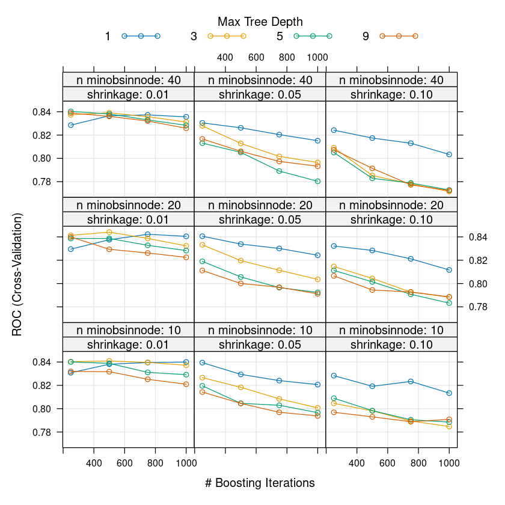

0.814528301886792

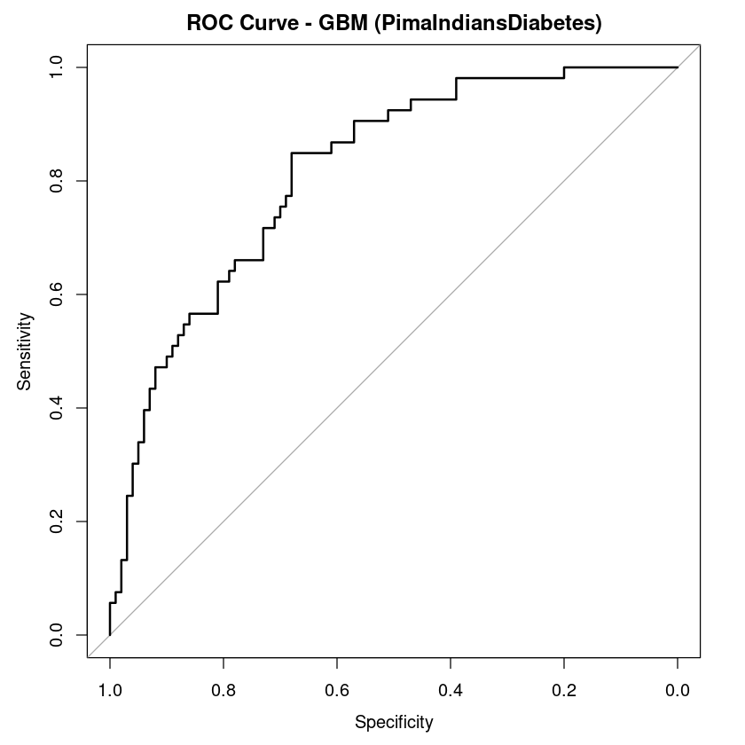

```r
# ---------------------------------------------------
# Set up GBM tuning grid & trainControl
#    NOTE: These are GBM parameters (NOT Random Forest/mtry).
# ---------------------------------------------------
# interaction.depth: tree depth (controls interaction order)
# n.trees          : total boosting iterations
# shrinkage        : learning rate
# n.minobsinnode   : min observations per leaf
gbmGrid = expand.grid(
  interaction.depth = c(1, 3, 5, 9),
  n.trees = seq(5, 20, by=5) * 50,        # from 250 to 1000
  shrinkage = c(0.01, 0.05, 0.1),
  n.minobsinnode = c(10, 20, 40)
)

# 10-fold CV, evaluate ROC; classProbs=TRUE required for ROC
trcn = trainControl(
  method = "cv",
  number = 10,
  classProbs = TRUE,
  summaryFunction = twoClassSummary,
  verboseIter = FALSE
)

# ---------------------------------------------------
#Train GBM model (optimize ROC)
# ---------------------------------------------------
set.seed(738)
gbm.fit = train(
  diabetes ~ .,
  data = train.dat,
  method = "gbm",
  trControl = trcn,
  tuneGrid = gbmGrid,
  metric = "ROC",
  verbose = FALSE
)

# Best tuning parameters
gbm.fit$bestTune
plot(gbm.fit)  # CV profile (optional)

# ---------------------------------------------------
# Evaluate on the test set
# ---------------------------------------------------
# Class probabilities (second column corresponds to "pos" probability if levels set as above)
prob.pos = predict(gbm.fit, newdata = test.dat, type = "prob")[, "pos"]
pred.cls = predict(gbm.fit, newdata = test.dat)

# Confusion matrix (explicitly set positive class = "pos")
confusionMatrix(pred.cls, test.dat$diabetes, positive = "pos")

# ROC & AUC
roc.obj = roc(response = test.dat$diabetes, predictor = prob.pos, levels = c("neg","pos"))
plot(roc.obj, main = "ROC Curve - GBM (PimaIndiansDiabetes)")
auc(roc.obj)
```

Sensitivity (also called true positive rate) measures how well the model catches people who actually have diabetes.

Specificity (also called true negative rate) measures how well the model identifies people who do not have diabetes.

The ROC curve shows how good the model is at separating positive cases from negative cases. the ROC curve helps us compare models and choose the best threshold for making decisions.

Example: Use Boston data to build a predictive model via GBMs to predict 'medv' using all predictors. Report the model performance on the testing data.

A Regression problem.

```r
#Use GBM to train a predictive model to predict house price in Boston housing data.
library(MASS)
library(tidyverse)
library(caret)
```

```r
#There are 14 varables:  medv is the price of house (response)
data(Boston)
str(Boston)

set.seed(252)


#Split the data
#Split the data into training and testing set according to medv

index = createDataPartition(Boston$medv, p = 0.8, list = FALSE)
train.dat = Boston[index,]
test.dat =  Boston[-index,]
```

```
'data.frame':	506 obs. of  14 variables:
 $ crim   : num  0.00632 0.02731 0.02729 0.03237 0.06905 ...
 $ zn     : num  18 0 0 0 0 0 12.5 12.5 12.5 12.5 ...
 $ indus  : num  2.31 7.07 7.07 2.18 2.18 2.18 7.87 7.87 7.87 7.87 ...
 $ chas   : int  0 0 0 0 0 0 0 0 0 0 ...
 $ nox    : num  0.538 0.469 0.469 0.458 0.458 0.458 0.524 0.524 0.524 0.524 ...
 $ rm     : num  6.58 6.42 7.18 7 7.15 ...
 $ age    : num  65.2 78.9 61.1 45.8 54.2 58.7 66.6 96.1 100 85.9 ...
 $ dis    : num  4.09 4.97 4.97 6.06 6.06 ...
 $ rad    : int  1 2 2 3 3 3 5 5 5 5 ...
 $ tax    : num  296 242 242 222 222 222 311 311 311 311 ...
 $ ptratio: num  15.3 17.8 17.8 18.7 18.7 18.7 15.2 15.2 15.2 15.2 ...
 $ black  : num  397 397 393 395 397 ...
 $ lstat  : num  4.98 9.14 4.03 2.94 5.33 ...
 $ medv   : num  24 21.6 34.7 33.4 36.2 28.7 22.9 27.1 16.5 18.9 ...
```

```r
# Model training using the caret package : train function
set.seed(295)

#Cross validation :  7 fold cross validaiton
ctrl = trainControl(method = "cv", number = 7)

# hyper-parameters:  ....
gbmGrid =  expand.grid(interaction.depth = c(6, 9, 12, 15),
                        n.trees = seq(8, 20, by=4)*50,
                        shrinkage = c(0.01, 0.05,0.1, 0.2),
                        n.minobsinnode = 20)

#train to find the optimal tuning parameters
n.fit = train(medv ~ ., data = train.dat,  method = "gbm",
                   trControl = ctrl,
                   tuneGrid = gbmGrid,
                   preProc = c("center", "scale")
)

#the best tuning parameters
n.fit$bestTune
```

A data.frame: 1 × 4

|  | n.trees <dbl> | interaction.depth <dbl> | shrinkage <dbl> | n.minobsinnode <dbl> |
| --- | --- | --- | --- | --- |
| 22 | 600 | 9 | 0.05 | 20 |

```r
#the best tuning parameters
n.fit$bestTune
```

A data.frame: 1 × 4

|  | n.trees <dbl> | interaction.depth <dbl> | shrinkage <dbl> | n.minobsinnode <dbl> |
| --- | --- | --- | --- | --- |
| 22 | 600 | 9 | 0.05 | 20 |

2.26075375085084

3.03288029785355

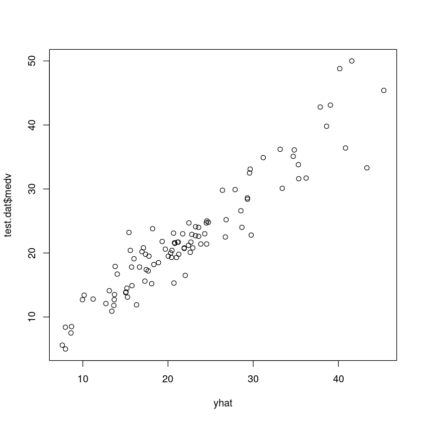

```r
#To make prediction using the testing data
yhat = predict(n.fit, test.dat)

#MAE on the testing data of the fitted model
caret::MAE(test.dat$medv, yhat)
#RMSE on the testing data of the fitted model
caret::RMSE(test.dat$medv, yhat)

#Plot the predicted value agaisnt the observed value
plot(yhat, test.dat$medv)
```

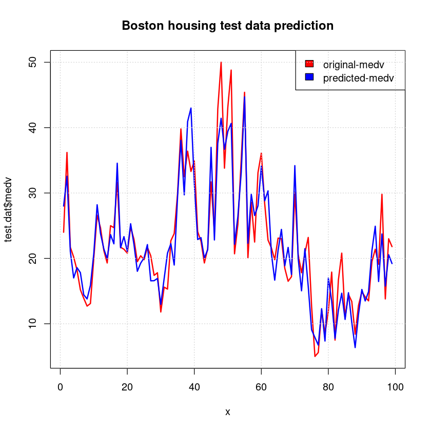

```r
#Line plots to see the performance
#Predicted value vs observed values
x = 1:length(yhat)
plot(x, test.dat$medv, col = "red", type = "l", lwd=2,
     main = "Boston housing test data prediction")
lines(x, yhat, col = "blue", lwd=2)
legend("topright",  legend = c("original-medv", "predicted-medv"),
       fill = c("red", "blue"), col = 2:3,  adj = c(0, 0.6))
grid()
```

```r
#Using gbm function in package gmb

library(gbm)
set.seed(1213)  # for reproducibility
fit.gbm1 <- gbm(medv ~ ., data = train.dat,
  distribution = "gaussian",  # SSE loss function , regression
  n.trees = 5000,
  shrinkage = 0.01,
  interaction.depth = 3,
  n.minobsinnode = 10,
  cv.folds = 10
)

# find index for number trees with minimum CV error
best <- which.min(fit.gbm1$cv.error)

# get MSE and compute RMSE
sqrt(fit.gbm1$cv.error[best])
```

3.20102337887228

```
Using 4793 trees...
```

1.99970587527801

2.6815930313758

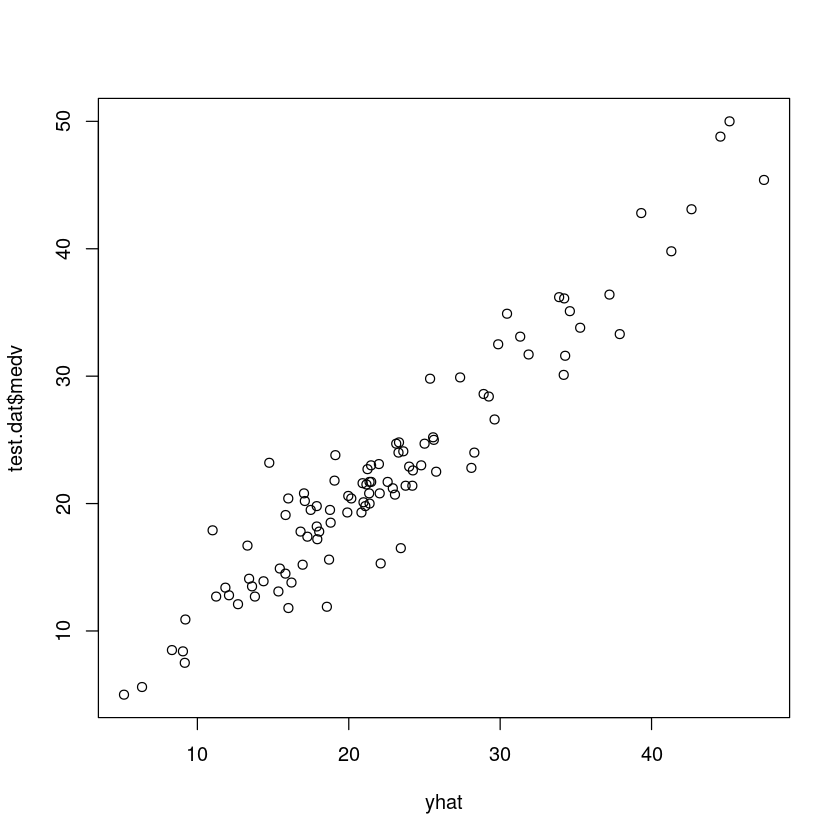

```r
#To make prediction using the testing data
yhat = predict(fit.gbm1, test.dat)

#MAE on the testing data of the fitted model
caret::MAE(test.dat$medv, yhat)
#RMSE on the testing data of the fitted model
caret::RMSE(test.dat$medv, yhat)

#Plot the predicted value agaisnt the observed value
plot(yhat, test.dat$medv)
```

```r
#XGBoost
library(caret)
library(xgboost)

grid_xgb = expand.grid(
  nrounds = c(500, 1000, 2000),
  max_depth = c(3, 4, 6),
  eta = c(0.03, 0.05, 0.1),           # learning rate
  gamma = c(0, 0.5, 1),              # min loss to split
  colsample_bytree = c(0.7, 0.9),    # feature subsampling
  min_child_weight = c(1, 5),        # minimum leaf weight
  subsample = c(0.7, 0.9)            # row subsampling
)

ctrl = trainControl(
  method = "cv",
  number = 5,
  verboseIter = FALSE
)

fit.xgb = train(
  medv ~ .,
  data = train.dat,
  method = "xgbTree",
  trControl = ctrl,
  tuneGrid = grid_xgb,
  metric = "RMSE"                  #For regression
)

fit.xgb$bestTune
```

[output not shown]

Excersie: In 'mlbench' package, there is 'Sonar' data. The goal is to classify sonar signals as either rock (R) or mine (M) based on energy patterns returned by sonar pulses.

# Source: UCI Machine Learning Repository.

Please build a predictive model using GBMs.

```r
library(mlbench)   # Sonar dataset
library(gbm)


data(Sonar)
#head(Sonar)
str(Sonar)

#Response: Class
```

```
'data.frame':	208 obs. of  61 variables:
 $ V1   : num  0.02 0.0453 0.0262 0.01 0.0762 0.0286 0.0317 0.0519 0.0223 0.0164 ...
 $ V2   : num  0.0371 0.0523 0.0582 0.0171 0.0666 0.0453 0.0956 0.0548 0.0375 0.0173 ...
 $ V3   : num  0.0428 0.0843 0.1099 0.0623 0.0481 ...
 $ V4   : num  0.0207 0.0689 0.1083 0.0205 0.0394 ...
 $ V5   : num  0.0954 0.1183 0.0974 0.0205 0.059 ...
 $ V6   : num  0.0986 0.2583 0.228 0.0368 0.0649 ...
 $ V7   : num  0.154 0.216 0.243 0.11 0.121 ...
 $ V8   : num  0.16 0.348 0.377 0.128 0.247 ...
 $ V9   : num  0.3109 0.3337 0.5598 0.0598 0.3564 ...
 $ V10  : num  0.211 0.287 0.619 0.126 0.446 ...
 $ V11  : num  0.1609 0.4918 0.6333 0.0881 0.4152 ...
 $ V12  : num  0.158 0.655 0.706 0.199 0.395 ...
 $ V13  : num  0.2238 0.6919 0.5544 0.0184 0.4256 ...
 $ V14  : num  0.0645 0.7797 0.532 0.2261 0.4135 ...
```

[output cut: 47 more lines]

```r
#Split the data into train set and test set
set.seed(252)

dat = Sonar

# Convert target to numeric (for gbm: 0/1)
#Sonar$Class <- ifelse(Sonar$Class == "M", 1, 0)
#
#dat$Class

#dat$Class = as.numeric(dat $ Class) - 1

dat$Class = ifelse(Sonar$Class == "M", 1, 0)
#dat$Class = as.numeric(dat$Class)

index = createDataPartition(Sonar$Class, p = 0.75, list = FALSE)
train.dat = dat[index,]
test.dat =   dat[-index,]
```

```r
set.seed(429)

fit.gbm = gbm(
  formula = Class ~ .,
  data = train.dat,
  distribution = "bernoulli",     # use "bernoulli" for classification
  n.trees = 5000,                # large upper bound; early stopping will choose best
  interaction.depth = 3,         # tree depth (controls interaction order)
  shrinkage = 0.03,              # learning rate
  n.minobsinnode = 20,           # minimum observations in each leaf
  bag.fraction = 0.7,            # subsampling rate for rows
  train.fraction = 0.8,          # reserve 20% for internal validation
  cv.folds = 10,                  # cross-validation for early stopping
  keep.data = FALSE,
  verbose = FALSE
)
```

309

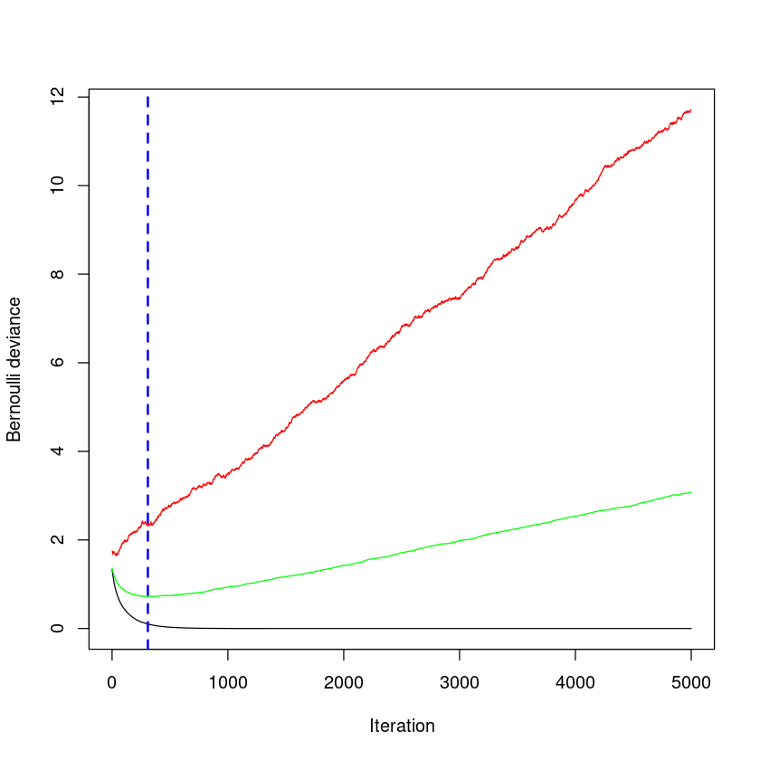

```r
# Pick best number of trees (via CV)
best_iter = gbm.perf(fit.gbm, method = "cv")   # "cv", "OOB", or "test"
best_iter


# Predict on validation set
pred.val = predict(
  fit.gbm,
  newdata = test.dat,
  n.trees = best_iter,
  type = "response"
)
```

```r
#Confusion matrix
#
threshod = 0.5
#Pred values for class : 1 (Mine),  0 (Rock)
pred.class = ifelse(pred.val > threshod, 1, 0)

confusionMatrix(as.factor(pred.class), as.factor(test.dat$Class), positive = '1')
```

```
Confusion Matrix and Statistics

          Reference
Prediction  0  1
         0 19  7
         1  5 20

               Accuracy : 0.7647
                 95% CI : (0.6251, 0.8721)
    No Information Rate : 0.5294
    P-Value [Acc > NIR] : 0.0004667

                  Kappa : 0.53

 Mcnemar's Test P-Value : 0.7728300

            Sensitivity : 0.7407
            Specificity : 0.7917
         Pos Pred Value : 0.8000
         Neg Pred Value : 0.7308
             Prevalence : 0.5294
         Detection Rate : 0.3922
   Detection Prevalence : 0.4902
      Balanced Accuracy : 0.7662

       'Positive' Class : 1
```

0.822530864197531

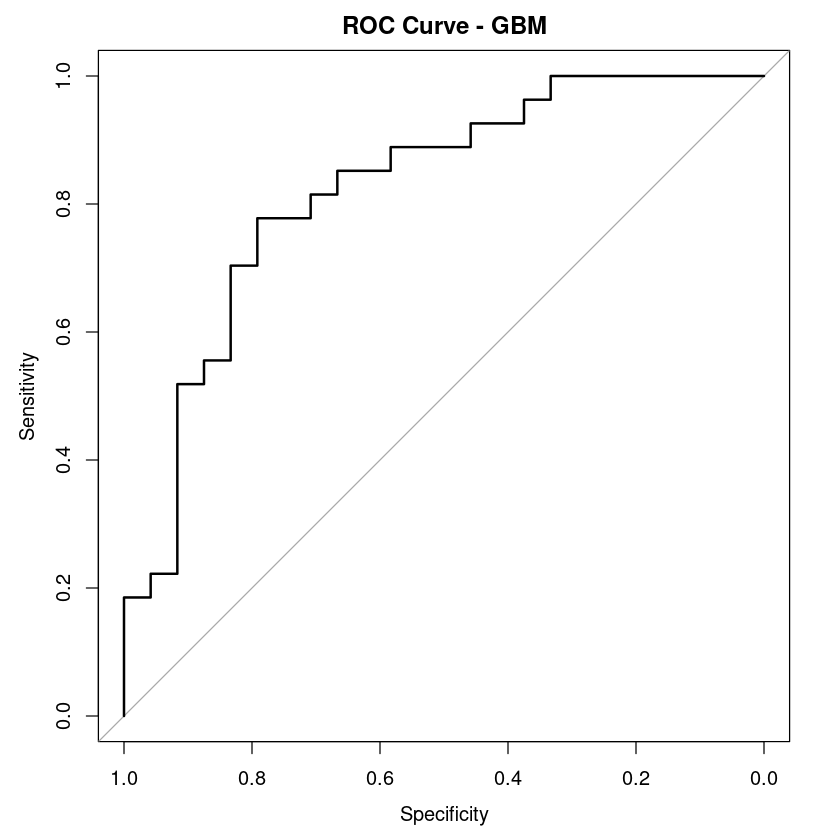

```r
#Sensitivity (also called true positive rate) measures how well the model catches 'Mine'.

#Specificity (also called true negative rate) measures how well the model identifies'Rock'

# ROC & AUC
roc.obj = roc(response = factor(test.dat$Class), predictor = pred.val, levels = c("0","1"))
plot(roc.obj, main = "ROC Curve - GBM")
auc(roc.obj)


#To see the performance of classfier for all threshods
#Roc curve
#AUC

#If threshold = 0,  all cases identified as 'Mine', even they are rocks.
```

```r
#To see the performance of classfier for all threshods
#Roc curve
#AUC
```